# Case Study 3

Group 97 - Visualization

Beccard, Leon - 12133103

Farmohammadi, Pouya - 52116495

Monteiro Oliveira, Guilherme - 12243299

2024-06-03

# Data

Load the data set you exported in the final Task of Case Study 2. Eliminate all observations with missing values in the income status variable.

```r
df <- read.csv('./final_dataset.csv')
nrow(df) # Result is 175
```

```
## [1] 175
```

```r
# Eliminate missing values in the income status variable
df <- df[!is.na(df$income_group), ]
nrow(df) # Result is the same 175, since we removed all rows consisting of at least one NA already in task 2
```

```
## [1] 175
```

```r
str(df)
```

```
## 'data.frame':    175 obs. of  7 variables:
##  $ country              : chr  "Monaco" "Japan" "Germany" "Italy" ...
##  $ median_age           : num  55.4 48.6 47.8 46.5 45.6 45.3 45.2 44.9 44.6 44.6 ...
##  $ net_migration_rate   : num  8.3 0 1.5 3.2 1.7 0.9 6.6 1.5 5.2 0.3 ...
##  $ youth_unemployed_rate: num  26.6 3.6 6.2 32.2 8.7 39.9 27.4 8.8 10.1 20.3 ...
##  $ income_group         : chr  "high income" "high income" "high income" "high income" ...
##  $ region               : chr  "western europe" "eastern asia" "western europe" "southern europe" ...
##  $ continent            : chr  "europe" "asia" "europe" "europe" ...
```

# a. Median age in different income levels

Using ggplot2, create a density plot of the median age grouped by income status groups. The densities for the different groups are superimposed in the same plot rather than in different plots. Ensure that you order the levels of the income status such that in the plots the legend is ordered from High (H) to Low (L).  
• The color of the density lines is black.  
• The area under the density curve should be colored differently among the income status levels.  
• For the colors, choose a transparency level of 0.5 for better visibility.  
• Position the legend at the top center of the plot and give it no title (hint: use element_blank()).  
• Rename the x axis as “Median age of population”  
Comment briefly on the plot.

### Answer

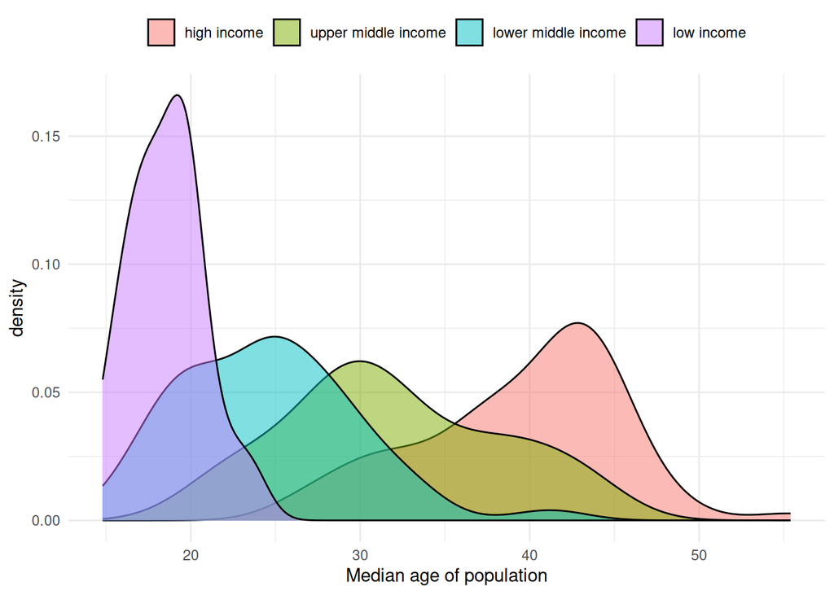

```r
df$income_group <- factor(df$income_group, levels = c("high income", "upper middle income", "lower middle income", "low income"))

plot <- ggplot(df, aes(x = median_age, fill = income_group) ) +
  geom_density(alpha = 0.5, color = "black") +
labs(x = "Median age of population") +
  theme_minimal()+
  theme(legend.position = "top",
        legend.title = element_blank())

plot
```

# b. Income status in different continents

Investigate how the income status is distributed in the different continents.  
• Using ggplot2, create a stacked barplot of absolute frequencies showing how the entities are split into continents and income status. Comment the plot.  
• Create another stacked barplot of relative frequencies (height of the bars should be one). Comment the plot.  
• Create a mosaic plot of continents and income status using base R functions.  
• Briefly comment on the differences between the three plots generated to investigate the income distribution among the different continents.

### Answer

As shown in this plot, Africa, Asia and Europe have the highest absolute frequencies of countries of approximately 40 countries each. Africa consists mostly of low income and lower middle income countries. Asia almost equally consists of lower middle, upper middle und high income countries. Whereas Europe mainly consists of high income countries and around one fifth of upper middle income countries. Neither in Europe, North America, Oceania nor in South America is a low income country placed.

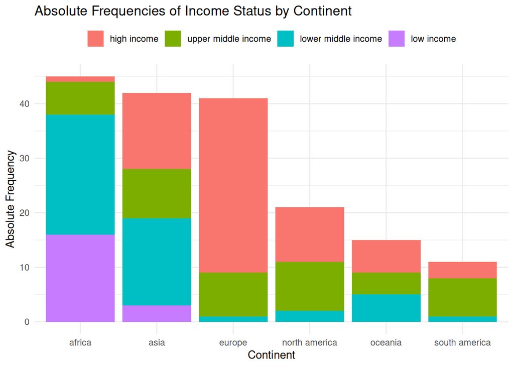

```r
# Aggregate data to get frequencies
df_agg <- df %>%
  count(continent, income_group)

ggplot(df_agg, aes(x = continent, y = n, fill = income_group)) +
  geom_bar(stat = "identity") +
  labs(title = "Absolute Frequencies of Income Status by Continent",
       x = "Continent", y = "Absolute Frequency") +
  theme_minimal()+
  theme(legend.position = "top",
        legend.title = element_blank())
```

• Create another stacked barplot of relative frequencies (height of the bars should be one). Comment the plot.

### Answer

With the relative frequency is given, it is easy to compare each income status per continent with each other. This can be done by providing the percentage of each country of a specific income group. For example South America has the biggest proportion of upper middle income countries than any other region, which is difficult to see in the absolute frequency plot. Also Asia, Oceania and South America have a similar proportion of high income countries.

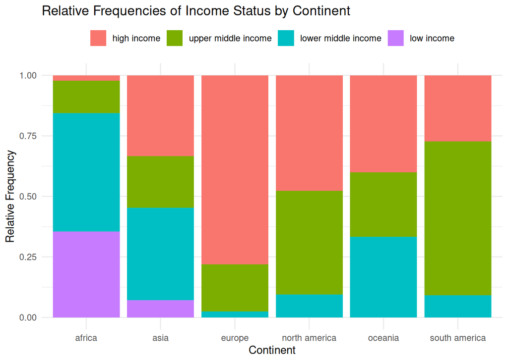

```r
# Calculate relative frequencies
df_relative <- df_agg %>%
  group_by(continent) %>%
  mutate(relative_frequency = n / sum(n))

ggplot(df_relative, aes(x = continent, y = relative_frequency, fill = income_group)) +
  geom_bar(stat = "identity") +
  labs(title = "Relative Frequencies of Income Status by Continent",
       x = "Continent", y = "Relative Frequency") +
  theme_minimal()+
  theme(legend.position = "top",
        legend.title = element_blank())
```

• Create a mosaic plot of continents and income status using base R functions.

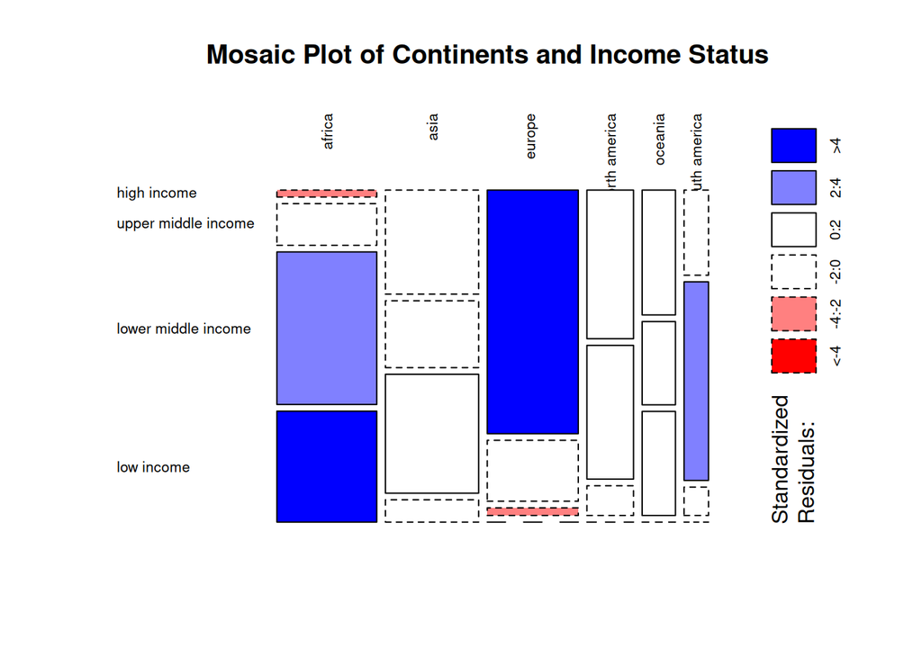

```r
# Create a contingency table
contingency_table <- table(df$continent, df$income_group)

# Mosaic plot
mosaicplot(contingency_table, main = "Mosaic Plot of Continents and Income Status", shade = TRUE, color = TRUE, las=2)
```

• Briefly comment on the differences between the three plots generated to investigate the income distribution among the different continents.

### Answer

With a stacked barplot of absolute frequencies the total amount can be investigated quickly between each continent. This makes it easy to analyze exact numbers of countries per continent but harder to compare continents by their income group with a different amount of countries. The stacked barplot of relative frequencies conveys a better understanding of occurrences of each income group per continent. This makes it far easier to compare continents with a significant difference of total countries by their income groups. The mosaic plot is not as intuitively as the other two plots. First, it can be easily observed that the distributions are the same of the relative frequency stacked barplot. The add-on is now the colouring of each rectangle with a meaning namely representing the standardized residual. As shown on the legend, the standardized residual with a positive value means that the observed count is higher than the expected count i.e. blue rectangles or white rectangles with a solid line this. The same meaning goes the other way around for negative residuals. This gives us the insight that especially Europe with their amount of high income countries and Africa with their amount of low income countries significantly differfrom what would be expected under the assumption of independence.

# c. Income status in different subcontinents

For Asia, investigate further how the income status distribution is in the different subcontinents. Use one of the plots in b. for this purpose. Comment on the results.

```r
# Filter the dataset for Asian countries
asia_subset <- subset(df, continent == "asia")

# Calculate relative frequencies
asia_data_rel <- asia_subset %>%
  group_by(region, income_group) %>%
  summarise(count = n()) %>%
  mutate(freq = count / sum(count))
```

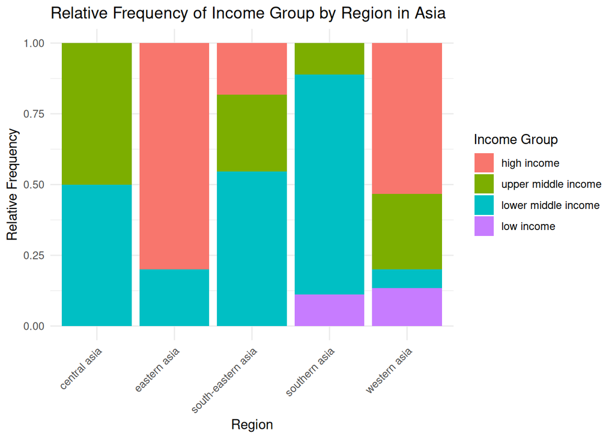

```r
# Create a bar plot of income group distribution by region
ggplot(asia_data_rel, aes(x = region, y = freq, fill = income_group)) +
  geom_bar(stat = "identity") +
  labs(title = "Relative Frequency of Income Group by Region in Asia",
       x = "Region",
       y = "Relative Frequency",
       fill = "Income Group") +
  theme_minimal() +
  theme(axis.text.x = element_text(angle = 45, hjust = 1))
```

Central asia, South-eastern asia and southern asia have mostly lower middle income countries. Even though for Central asia this is not totally correct since it has just as many upper middle income countries as well. Eastern asia and western asia on the opposite have mainly high income countries. Only western asia consists of all income groups whereas the other subcontinents have at least one (south-eastern asia and souther asia) or two income groups (central asia and eastern asia) missing.

# d. Net migration in different continents

• Using ggplot2, create parallel boxplots showing the distribution of the net migration rate in the different continents.  
• Prettify the plot (change y-, x-axis labels, etc).  
• Identify which country in Asia constitutes the largest negative outlier and which country in Asia constitutes the largest positive outlier.  
• Comment on the plot.

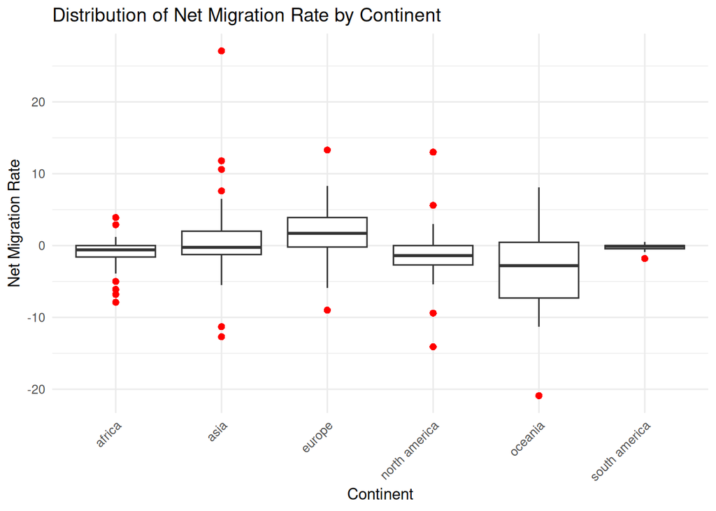

```r
ggplot(df, aes(x = continent, y = net_migration_rate)) +
  geom_boxplot(outlier.color = "red", outlier.shape = 16, outlier.size = 2) +
  labs(title = "Distribution of Net Migration Rate by Continent",
       x = "Continent",
       y = "Net Migration Rate") +
  theme_minimal() +
  theme(axis.text.x = element_text(angle = 45, hjust = 1))
```

### Answer

In the plot we can observe Oceania has the highest distribution of net migration rate with the biggest interquartile range and the longest whiskers. 50% of its data is approximately between 0 and -7.5 and its median of -3.5. Europe and Asia also have a higher interquartile range in terms of the net migration rate. Especially Asia stands out with a lot of outliers. On the other hand Africa, North America and South America all have relatively small boxplots around zero meaning that their interquartile range is not as high besides several outliers. Especially for South America it seems that almost every country has a net migration of 0 with only one outlier, which is still quite close to the interquartile range at approximately -2.

```r
# Identify the largest negative and positive outliers in Asia
asia_data <- df %>% filter(continent == "asia")

largest_negative_outlier <- asia_data %>% filter(net_migration_rate == min(net_migration_rate))
largest_positive_outlier <- asia_data %>% filter(net_migration_rate == max(net_migration_rate))

largest_negative_outlier
```

```
##    country median_age net_migration_rate youth_unemployed_rate
## 1 Maldives       29.5              -12.7                  15.9
##          income_group        region continent
## 1 upper middle income southern asia      asia
```

```r
largest_positive_outlier
```

```
##   country median_age net_migration_rate youth_unemployed_rate income_group
## 1   Syria       23.5               27.1                  35.8   low income
##         region continent
## 1 western asia      asia
```

# e. Net migration in different subcontinents

The graph in d. clearly does not convey the whole picture. It would be interesting also to look at the subcontinents, as it is likely that a lot of migration flows happen within the continent.  
• Investigate the net migration in different subcontinents using again parallel boxplots. Group the boxplots by continent (hint: use facet_grid with scales = “free_x”).  
• Remember to prettify the plot (rotate axis labels if needed).  
• Describe what you see.

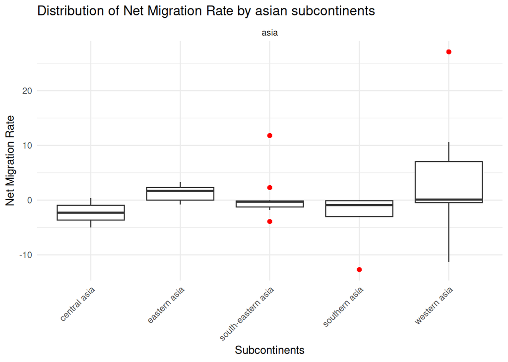

```r
ggplot(asia_subset, aes(x = region, y = net_migration_rate)) +
  geom_boxplot(outlier.color = "red", outlier.shape = 16, outlier.size = 2) +
  facet_grid(. ~ continent, scales = "free_x") +
  labs(title = "Distribution of Net Migration Rate by asian subcontinents",
       x = "Subcontinents",
       y = "Net Migration Rate") +
  theme_minimal() +
  theme(axis.text.x = element_text(angle = 45, hjust = 1))
```

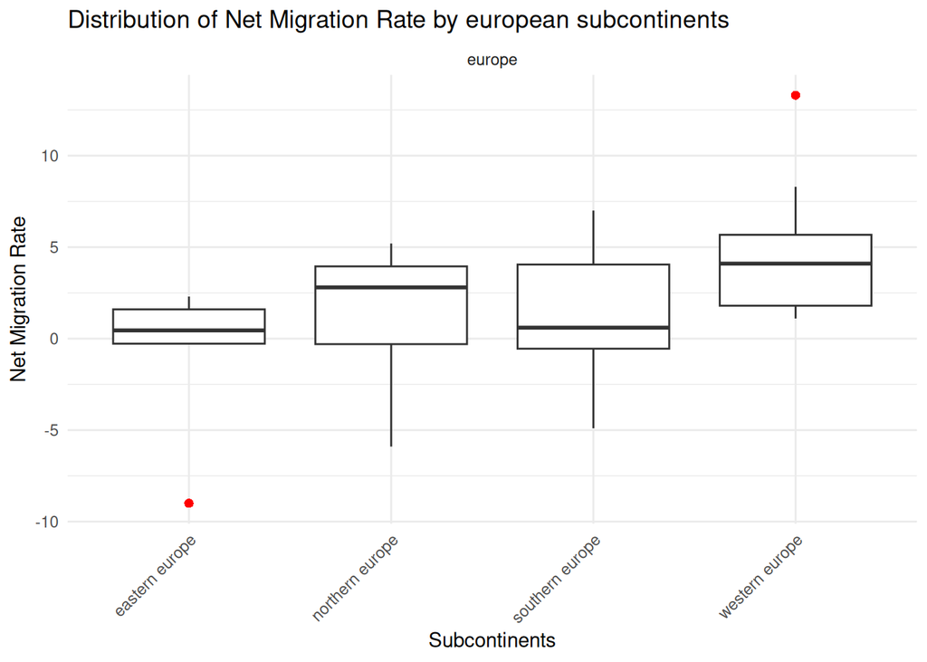

```r
europe_subset <- subset(df, continent== 'europe')

ggplot(europe_subset, aes(x = region, y = net_migration_rate)) +
  geom_boxplot(outlier.color = "red", outlier.shape = 16, outlier.size = 2) +
  facet_grid(. ~ continent, scales = "free_x") +
  labs(title = "Distribution of Net Migration Rate by european subcontinents",
       x = "Subcontinents",
       y = "Net Migration Rate") +
  theme_minimal() +
  theme(axis.text.x = element_text(angle = 45, hjust = 1))
```

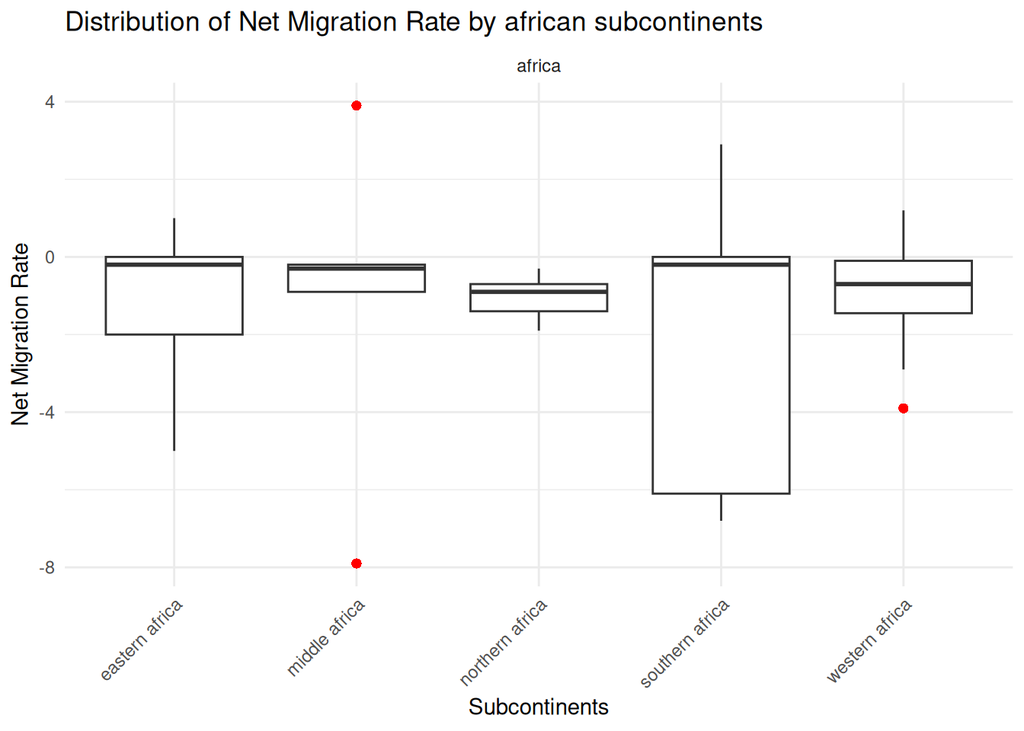

```r
africa_subset <- subset(df, continent== 'africa')

ggplot(africa_subset, aes(x = region, y = net_migration_rate)) +
  geom_boxplot(outlier.color = "red", outlier.shape = 16, outlier.size = 2) +
  facet_grid(. ~ continent, scales = "free_x") +
  labs(title = "Distribution of Net Migration Rate by african subcontinents",
       x = "Subcontinents",
       y = "Net Migration Rate") +
  theme_minimal() +
  theme(axis.text.x = element_text(angle = 45, hjust = 1))
```

### Answer

For Africa, there are five subcontients. Middle africa has two outliers. One with the highest and one with the lowest net migration rate overall in Africa. Middle and northern africa have a very small IQR and almost no whiskers, staying between 0 and -2. Western and eastern africa have relatively bigger IQR than the one before filling up the whole range of 0 to -2. Again, there is one subcontinent namely southern africa with a high IQR comparatively with a range from 0 to -6. Its median though is close to 0, which means that the distribution of this subcontinent is left-skewed and there are many countries with a net migration rate of around zero.

# f. Median net migration rate per subcontinent

The plot in task e. shows the distribution of the net migration rate for each subcontinent. Here you will work on visualizing only one summary statistic, namely the median.  
For each subcontinent, calculate the median net migration rate. Then create a plot which contains the sub-regions on the y-axis and the median net migration rate on the x-axis.  
• As geoms use points.  
• Color the points by continent – use a colorblind friendly palette (see e.g., here).  
• Rename the axes.  
• Using fct_reorder from the forcats package, arrange the levels of subcontinent such that in the plot the lowest (bottom) subcontinent contains the lowest median net migration rate and the upper most region contains the highest median net migration rate.  
• Comment on the plot. E.g., what are the regions with the most influx? What are the regions with the most outflux?

### Answer

As shown in the plot below, the subcontinent with the highest median net migration rate i.e. the most influx is Australia and New Zealand with a median of around 7.5. The subcontinent with the lowest median net migration rate i.e. the most outflux is Micronesia with a median of around -7.5. The continent Oceania has both the subcontinents with the most influx and outflux, which seems quite interesting and might be a correlation of people of one subcontinent (Micronesia) migrating to the other subcontinent (Australia and New Zealand).

```r
library(forcats)
# Rename variable region to subcontinent
df$subcontinent <- df$region
df$region<-NULL

# Add the colourblind palette with black:
cbbPalette <- c("#000000", "#E69F00", "#56B4E9", "#009E73", "#F0E442", "#0072B2", "#D55E00", "#CC79A7")

median_migration <- df %>%
  group_by(subcontinent, continent) %>%
  summarize(median_net_migration_rate = median(net_migration_rate, na.rm = TRUE))
```

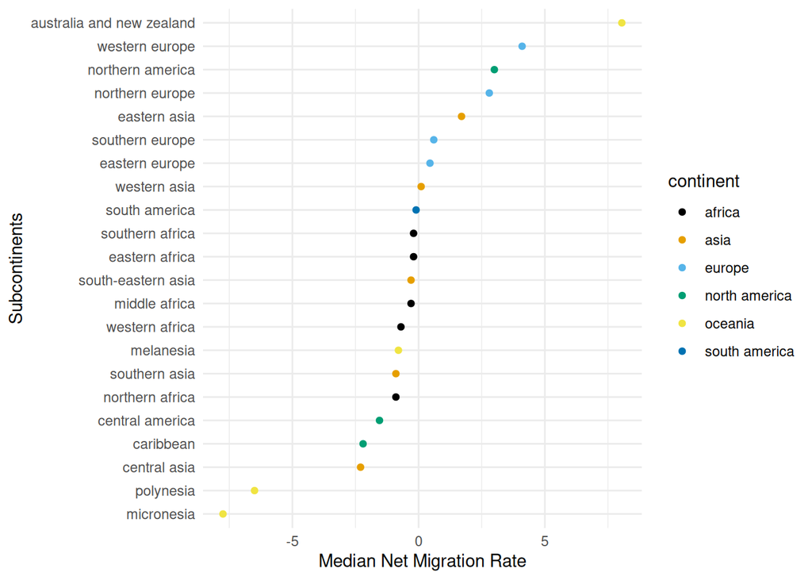

```r
ggplot(median_migration, aes(x = median_net_migration_rate, y = fct_reorder(subcontinent, median_net_migration_rate), color = continent)) +
  geom_point() +
  labs(x = "Median Net Migration Rate", y = "Subcontinents") +
  theme_minimal() +
  scale_color_manual(values = cbbPalette)
```

# g Median youth unemployment rate per subcontinent

For each subcontinent, calculate the median youth unemployment rate. Then create a plot which contains the sub-regions on the y-axis and the median unemployment rate on the x-axis.  
• Use a black and white theme (?theme_bw())  
• As geoms use bars. (hint: pay attention to the statistical transformation taking place in geom_bar() – look into argument stat=“identity”)  
• Color the bars by continent – use a colorblind friendly palette.  
• Make the bars transparent (use alpha = 0.7).  
• Rename the axes.  
• Using fct_reorder from the forcats package, arrange the levels of subcontinent such that in the plot the lowest (bottom) subcontinent contains the lowest median youth unemployment rate and the upper most region contains the highest median youth unemployment rate.  
• Comment on the plot. E.g., what are the regions with the highest vs lowest youth unemployment rate?

### Answer

As shown in the plot below, the subcontinent with the highest median youth unemployment rate is Southern Africa with a median of almost 40. The subcontinent with the lowest median youth unemployment rate is Eastern Asia with a median of around 8. Here, the colorblind friendly palette is used to color the bars by continent, but to me makes it more difficult to distinguish the continents from each other than it was before.

```r
# Calculate median youth unemployment rate for each subcontinent
median_unemployment <- df %>%
  group_by(subcontinent, continent) %>%
  summarize(youth_unemployed_rate = median(youth_unemployed_rate, na.rm = TRUE))
```

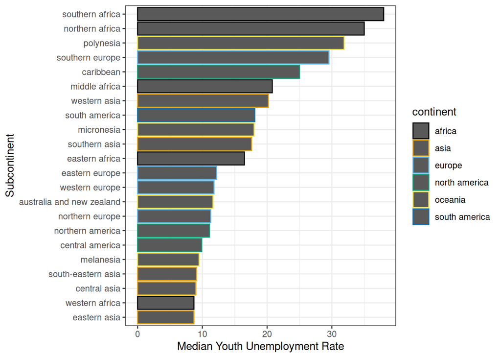

```r
ggplot(median_unemployment, aes(x = youth_unemployed_rate, y = fct_reorder(subcontinent, youth_unemployed_rate), color = continent)) +
  geom_bar(stat = "identity") +
  labs(x = "Median Youth Unemployment Rate", y = "Subcontinent") +
  theme_bw() +
  scale_color_manual(values = cbbPalette)
```

# h. Median youth unemployment rate per subcontinent – with error bars

The value displayed in the barplot in g. is the result of an aggregation, so it might be useful to also plot error bars, to have a general idea on how precise the median unemployment is. This can be achieved by plotting the error bars which reflect the standard deviation or the interquartile range of the variable in each of the subcontinents.  
Repeat the plot in h. but include also error bars which reflect the 25% and 75% quantiles. You can use geom_errorbar in ggplot2.

```r
# Task h: Median youth unemployment rate per subcontinent – with error bars
unemployment_stats <- df %>%
  group_by(subcontinent, continent) %>%
  summarize(median_youth_unemployment_rate = median(youth_unemployed_rate, na.rm = TRUE),
            Q1 = quantile(youth_unemployed_rate, 0.25, na.rm = TRUE),
            Q3 = quantile(youth_unemployed_rate, 0.75, na.rm = TRUE))
```

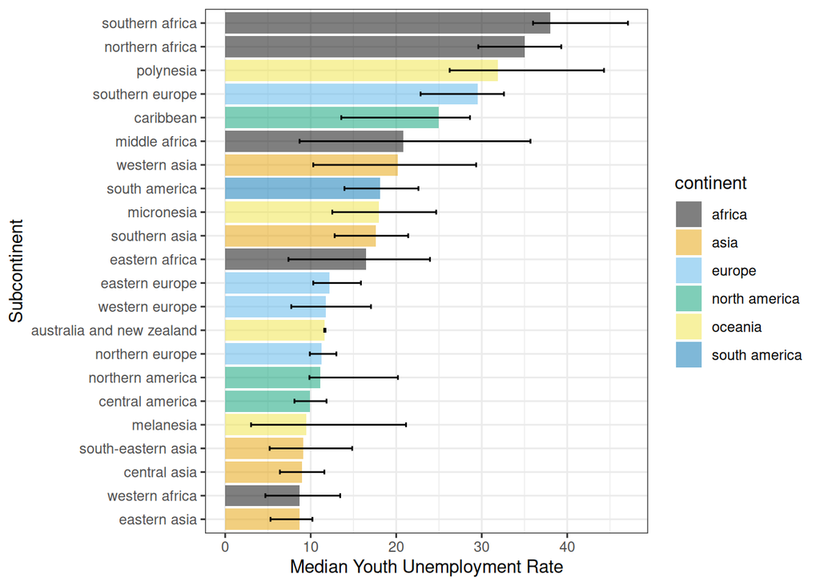

```r
ggplot(unemployment_stats, aes(x = median_youth_unemployment_rate, y = fct_reorder(subcontinent, median_youth_unemployment_rate), fill = continent)) +
  geom_bar(stat = "identity", alpha = 0.5) +
  geom_errorbar(aes(xmin = Q1, xmax = Q3), width = 0.2) +
  labs(x = "Median Youth Unemployment Rate", y = "Subcontinent") +
  theme_bw() +
  scale_fill_manual(values = cbbPalette)
```

# i. Relationship between median age and net migration rate

Using ggplot2, create a plot showing the relationship between median age and net migration rate.  
• Color the geoms based on the income status.  
• Add a regression line for each development status (using geom_smooth()).  
Comment on the plot. Do you see any relationship between the two variables? Do you see any difference among the income levels?

### Answer

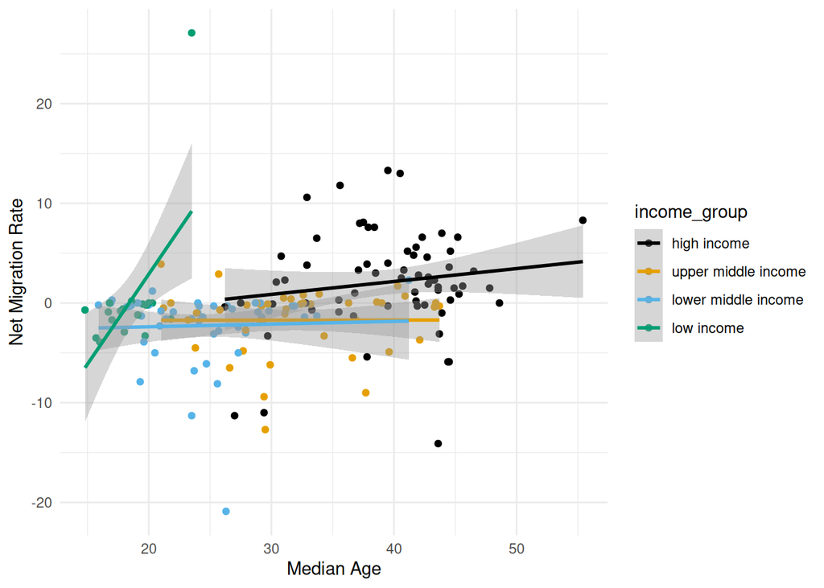

```r
# Relationship between median age and net migration rate
ggplot(df, aes(x = median_age, y = net_migration_rate, color = income_group)) +
  geom_point() +
  geom_smooth(method = "lm") +
  labs(x = "Median Age", y = "Net Migration Rate") +
  theme_minimal() +
  scale_color_manual(values = cbbPalette)
```

# j. Relationship between youth unemployment and net migration rate

Create a plot as in Task i. but for youth unemployment and net migration rate. Comment briefly.

### Answer

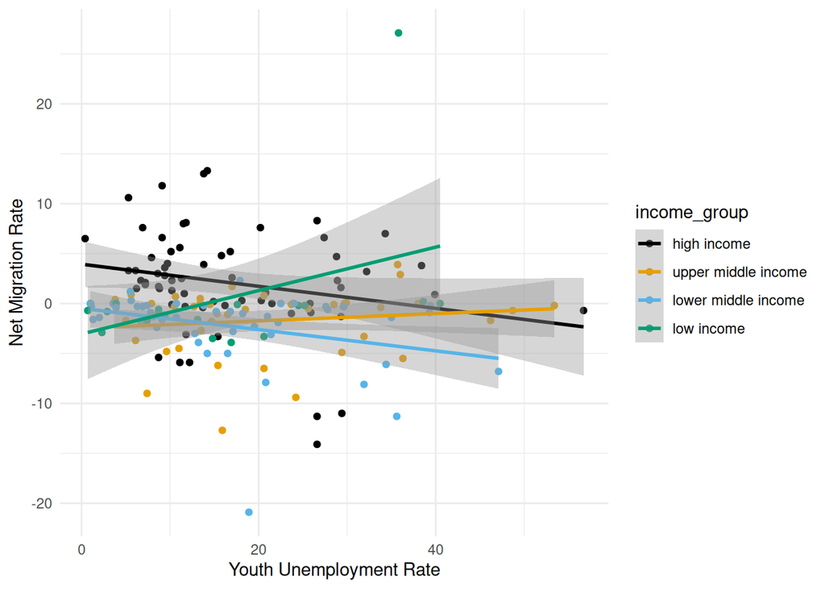

```r
# Relationship between youth unemployment and net migration rate
ggplot(df, aes(x = youth_unemployed_rate, y = net_migration_rate, color = income_group)) +
  geom_point() +
  geom_smooth(method = "lm") +
  labs(x = "Youth Unemployment Rate", y = "Net Migration Rate") +
  theme_minimal() +
  scale_color_manual(values = cbbPalette)
```

# k. Merging population data

Go online and find a data set which contains the 2020 population for the countries of the world together with ISO codes.

- Download this data and merge it to the dataset you are working on in this case study using a left join. (A possible source: World Bank))
- Inspect the data and check whether the join worked well.

## Answer

```r
# Load the population data
population_data <- read_csv("./API_SP.POP.TOTL_DS2_en_csv_v2_45183.csv", skip = 4)
```

```
## ──────────────────────────────────────────────────────── Delimiter: "," chr
## (4): Country Name, Country Code, Indicator Name, Indicator Code dbl (63): 1960,
## 1961, 1962, 1963, 1964, 1965, 1966, 1967, 1968, 1969, 1970, ... lgl (2): 2023,
## ...69
```

```r
population_data <- population_data %>%
  select(`Country Name`, `Country Code`, `2020`) %>%
  rename(country = `Country Name`, iso_code = `Country Code`, population = `2020`)

# merge

df <- left_join(df, population_data, by = c("country" = "country"))
```

# l. Scatterplot of median age and net migration rate in Europe

Make a scatterplot of median age and net migration rate for the countries of Europe. * Scale the size of the points according to each country’s population.

- For better visibility, use a transparency of alpha=0.7.
- Remove the legend.
- Comment on the plot.

# m. Interactive plot

On the merged data set from Task k., using function ggplotly from package plotly re-create the scatterplot in Task l., but this time for all countries. Color the points according to their continent.

When hovering over the points the name of the country, the values for median age, net migration rate, and population should be shown. (Hint: use the aesthetic text = Country. In ggplotly use the argument `tooltip = c("text", "x", "y", "size")).`

# n. Parallel coordinate plot

In parallel coordinate plots each observation or data point is depicted as a line traversing a series of parallel axes, corresponding to a specific variable or dimension. It is often used for identifying clusters in the data.

One can create such a plot using the GGally R package. You should create such a plot where you look at the three main variables in the data set: median age, youth unemployment rate and net migration rate. Color the lines based on the income status. Briefly comment

# o. World map visualisation

Using the package rworldmap, create a world map of the median age per country. Use the vignette https://cran.r-project.org/web/packages/rworldmap/vignettes/rworldmap.pdf to find how to do this in R.